# R Notebook

```r
ars_fluxes<-read_csv("../data/ars/ars_fluxes.csv", skip = 2)
fluxes<-ars_fluxes%>%
  select(`Experimental Unit ID`, Date, N2O, Air_Temp, Soil_Temp, Soil_Moisture)%>%
  mutate(Date = mdy_hms(Date))%>%
  separate(`Experimental Unit ID`, c("state","exp"), sep = 3)
head(fluxes)
```

| state | exp | Date | N2O | Air_Temp | Soil_Temp | Soil_Moisture |
| --- | --- | --- | --- | --- | --- | --- |
| ALA | uburn_04drain11r1 | 2004-05-12 | 0.0023322 | 23.333333 | 30.27769 | 8.691466 |
| ALA | uburn_04drain11r1 | 2004-08-05 | -0.0003510 | 29.166667 | 29.59308 | 2.868987 |
| ALA | uburn_04drain11r1 | 2004-10-27 | 0.0270738 | 21.666667 | 22.62385 | 16.071906 |
| ALA | uburn_04drain11r1 | 2006-01-26 | 0.0005811 | 5.833333 | NA | 17.546356 |
| ALA | uburn_04drain12r2 | 2004-05-12 | 0.0006903 | 23.333333 | 30.27769 | 7.990868 |
| ALA | uburn_04drain12r2 | 2004-08-05 | 0.0000429 | 29.166667 | 29.59308 | 2.949503 |

```r
ars_weather<-read_csv("../data/ars/ars_weather.csv", skip = 2)
weather<-ars_weather%>%
  select(`Site ID`, Date, `Temperate, air, daily, maximum, degrees Celsius`, `Temperate, air, daily, minimum, degrees Celsius`, Precip, `Total_Net_Radn`)%>%
  mutate(Date = mdy_hms(Date))%>%
  separate(`Site ID`, c("state","exp"), sep = 3)%>%
  filter(state != "ORP")
head(weather)
```

| state | exp | Date | Temperate, air, daily, maximum, degrees Celsius | Temperate, air, daily, minimum, degrees Celsius | Precip | Total_Net_Radn |
| --- | --- | --- | --- | --- | --- | --- |
| ALA | uburn | 2004-01-01 | 17.77778 | -2.7777778 | 0.000 | NA |
| ALA | uburn | 2004-01-02 | 21.11111 | -0.5555556 | 0.000 | NA |
| ALA | uburn | 2004-01-03 | 19.44444 | 6.1111111 | 0.000 | NA |
| ALA | uburn | 2004-01-04 | 23.33333 | 13.8888889 | 0.000 | NA |
| ALA | uburn | 2004-01-05 | 22.77778 | 15.0000000 | 0.000 | NA |
| ALA | uburn | 2004-01-06 | 22.77778 | 1.6666667 | 4.826 | NA |

```r
ars_latlong<-read_csv("../data/ars/ars_latlong.csv")
latlong<-ars_latlong%>%
  select(`Experimental Unit`, `Latitude of weather station, decimal degrees`, `Longitude of weather station, decimal degrees`)%>%
  rename(lat = `Latitude of weather station, decimal degrees`, long = `Longitude of weather station, decimal degrees`)%>%
  separate(`Experimental Unit`, c("state","exp"), sep = 3)%>%
  filter(state != "ORP")
head(latlong)
```

| state | exp | lat | long |
| --- | --- | --- | --- |
| ALA | uburn | 32.45000 | -85.8800 |
| KYG | HG | 36.93000 | -86.4700 |
| NEM | EIRR | 41.09000 | -96.2400 |
| NEM | ERREM | 41.15000 | -96.4000 |
| TXL | ULIB1 | 33.68456 | -101.7668 |
| NDH | 3 | 46.81209 | -100.9107 |

[output not shown]

Does not seem like I use this daymet data. . .yet.

```r
daymet_mandan<-read_csv("../data/ars/daymet_mandan.csv", skip = 7)
daymet_mandan$town<-"Mandan"
daymet_morris<-read_csv("../data/ars/daymet_morris.csv", skip = 7)
daymet_morris$town<-"Morris"
daymet_roseville<-read_csv("../data/ars/daymet_roseville.csv", skip = 7)
daymet_roseville$town<-"Roseville"
daymet_university_park<-read_csv("../data/ars/daymet_university_park.csv", skip = 7)
daymet_university_park$town<-"University_Park"
daymet_west_lafayette<-read_csv("../data/ars/daymet_west_lafayette.csv", skip = 7)
daymet_west_lafayette$town<-"West_Lafayette"
daymet<-rbind(daymet_mandan, daymet_morris, daymet_roseville, daymet_university_park, daymet_west_lafayette)
daymet$date<-as.Date(strptime(paste(daymet$year, daymet$yday), format="%Y%j"))
colnames(daymet)<-c("year", "yday", "daymet_prcp", "daymet_radn", "daymet_tmax", "daymet_tmin", "town", "date")
#daymet<-mutate(daymet, if_else )
head(daymet)
```

| year | yday | daymet_prcp | daymet_radn | daymet_tmax | daymet_tmin | town | date |
| --- | --- | --- | --- | --- | --- | --- | --- |
| 2004 | 1 | 0 | 169.6 | -6.0 | -18.0 | Mandan | 2004-01-01 |
| 2004 | 2 | 0 | 163.2 | -6.5 | -17.5 | Mandan | 2004-01-02 |
| 2004 | 3 | 0 | 150.4 | -15.0 | -24.5 | Mandan | 2004-01-03 |
| 2004 | 4 | 0 | 140.8 | -18.5 | -27.0 | Mandan | 2004-01-04 |
| 2004 | 5 | 0 | 169.6 | -18.5 | -29.5 | Mandan | 2004-01-05 |
| 2004 | 6 | 0 | 153.6 | -14.0 | -23.5 | Mandan | 2004-01-06 |

```r
ars<-left_join(weather, fluxes, by=c("state", "Date"))
ars<-left_join(ars, soils, by = c("state", "exp"))
ars<-left_join(ars, ars_soils, by = "series" )
#ars<-left_join(ars, latlong, by = "state")


colnames(ars)<-c("site", "nada", "date", "max_temp", "min_temp", "precip", "radn", "exp", "N2O", "air_temp", "soil_temp", "soil_moisture", "exp.again", "lat", "long", "again.exp", "series")

head(ars)
```

[output not shown]

```r
get_soil_data <- function(series){
  horizons(fetchKSSL(series))%>%
    select(pedon_key, hzn_desgn, sand, silt, clay, oc, ph_h2o)%>%
    filter(grepl('A', hzn_desgn))%>%
    select(-c(hzn_desgn, pedon_key))%>%
    summarise_each(funs(mean(., na.rm = TRUE)))%>%
    mutate(series = series)
}
brute_errors<-lapply(our_soils$dom_soil, function(series) try(get_soil_data(series)))
```

[output not shown]

[output cut: 17 more lines]

```r
ars_soils<-bind_rows(Filter(function(series) !inherits(series, "try-error"), brute_errors))
```

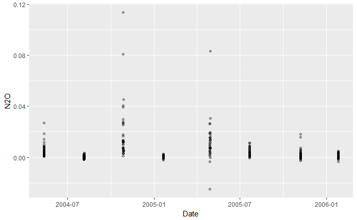

```r
filter(fluxes, state == "ALA")%>%
ggplot((aes(x = Date, y = N2O)))+
  geom_jitter(alpha = .3)
```

```r
ggplot(ars, (aes(x = as.factor(lat), y = N2O)))+
  geom_jitter(alpha =.3)
```

```
Error: cannot allocate vector of size 287.8 Mb
```

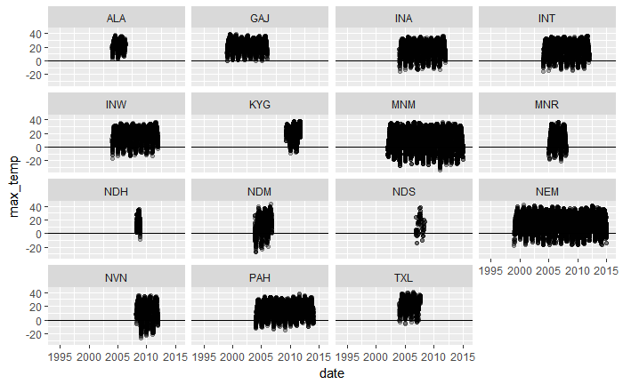

```r
ggplot(ars, (aes(x = date, y = max_temp)))+
  geom_point(alpha = .3)+
  geom_hline(yintercept=0)+
  facet_wrap(~site)
```

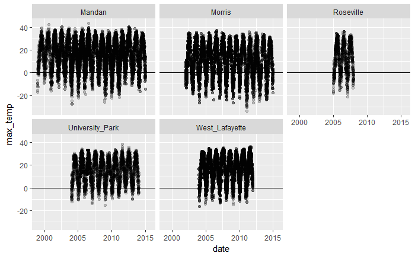

```r
ars_cold<-ars %>% filter(site %in% c("INA", "INT", "INW", "MNM", "MNR", "NDM", "NEM", "NVN", "PAH"))%>%
   mutate(town = ifelse((site %in% c("INA", "INT", "INW")), "West_Lafayette",
                        ifelse((site == "MNM"), "Morris",
                               ifelse((site == "MNR"), "Roseville",
                                      ifelse((site %in% c("NDM", "NEM", "NVN")), "Mandan",
                                            ifelse((site == "PAH"), "University_Park", "NA"                                                                                           ))))))%>%
  mutate(month=month(date, label=TRUE), year = as.factor(year(date)), date = as.Date(date))%>%
  filter(N2O < 1500 | is.na(N2O))
ggplot(ars_cold, (aes(x = date, y = max_temp)))+
  geom_point(alpha = .2)+
  geom_hline(yintercept=0)+
  facet_wrap(~town)
```

```r
both_ars_cold<-right_join(daymet, ars_cold, by = c("date", "town"))
```

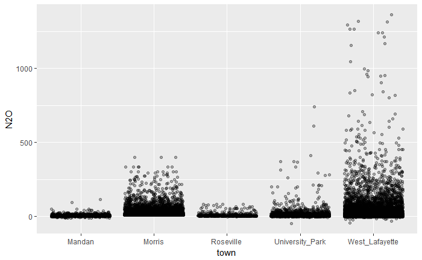

```r
ggplot(ars_cold, (aes(x = town, y = N2O)))+
  geom_jitter(alpha = .3)
```

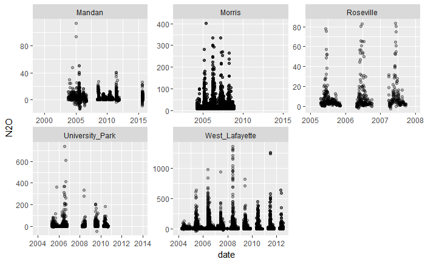

```r
ggplot(ars_cold, (aes(x = date, y = N2O)))+
  geom_point(alpha = .3)+
  facet_wrap(~town, scales = "free")
```

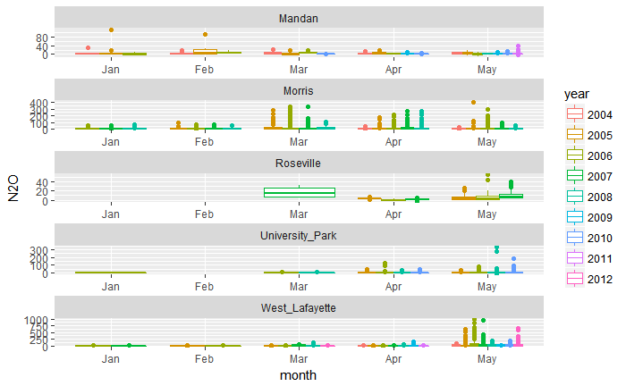

```r
ggplot(data = filter(ars_cold, month %in% c("Jan", "Feb", "Mar", "Apr", "May")) , aes(x=month, y=N2O, color = year))+
  geom_boxplot()+
  facet_wrap(~town, scales = "free", nrow=5)
```

[figure not shown]

```r
ggplot(data=filter(ars_cold, town == "Mandan", air_temp != "NA"), aes(x=air_temp, y=N2O, color = year))+
  geom_jitter(alpha=.3)#+
```

```r
 # facet_wrap(~year, scales = "free")
head(ars_cold)
```

| site | nada | date | max_temp | min_temp | precip | radn | exp | N2O | air_temp | soil_temp | soil_moisture | town | month | year |
| --- | --- | --- | --- | --- | --- | --- | --- | --- | --- | --- | --- | --- | --- | --- |
| INA | CRE | 2004-01-01 | 8.2 | -1.6 | NA | NA | NA | NA | NA | NA | NA | West_Lafayette | Jan | 2004 |
| INA | CRE | 2004-01-02 | 11.5 | -1.9 | NA | NA | NA | NA | NA | NA | NA | West_Lafayette | Jan | 2004 |
| INA | CRE | 2004-01-03 | 17.0 | 9.2 | NA | NA | NA | NA | NA | NA | NA | West_Lafayette | Jan | 2004 |
| INA | CRE | 2004-01-04 | 16.8 | 2.0 | NA | NA | NA | NA | NA | NA | NA | West_Lafayette | Jan | 2004 |
| INA | CRE | 2004-01-05 | 2.2 | -0.9 | NA | NA | NA | NA | NA | NA | NA | West_Lafayette | Jan | 2004 |
| INA | CRE | 2004-01-06 | -0.8 | -13.2 | NA | NA | NA | NA | NA | NA | NA | West_Lafayette | Jan | 2004 |

```r
ars_spring<-ars_cold%>% filter(month %in% c("Jan", "Feb", "Mar", "Apr", "May"))
head(ars_spring)
```

| site | nada | date | max_temp | min_temp | precip | radn | exp | N2O | air_temp | soil_temp | soil_moisture | town | month | year |
| --- | --- | --- | --- | --- | --- | --- | --- | --- | --- | --- | --- | --- | --- | --- |
| INA | CRE | 2004-01-01 | 8.2 | -1.6 | NA | NA | NA | NA | NA | NA | NA | West_Lafayette | Jan | 2004 |
| INA | CRE | 2004-01-02 | 11.5 | -1.9 | NA | NA | NA | NA | NA | NA | NA | West_Lafayette | Jan | 2004 |
| INA | CRE | 2004-01-03 | 17.0 | 9.2 | NA | NA | NA | NA | NA | NA | NA | West_Lafayette | Jan | 2004 |
| INA | CRE | 2004-01-04 | 16.8 | 2.0 | NA | NA | NA | NA | NA | NA | NA | West_Lafayette | Jan | 2004 |
| INA | CRE | 2004-01-05 | 2.2 | -0.9 | NA | NA | NA | NA | NA | NA | NA | West_Lafayette | Jan | 2004 |
| INA | CRE | 2004-01-06 | -0.8 | -13.2 | NA | NA | NA | NA | NA | NA | NA | West_Lafayette | Jan | 2004 |

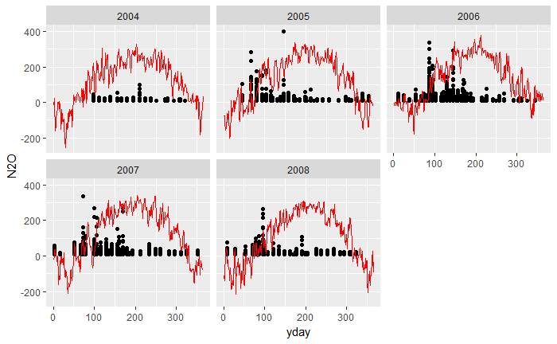

```r
ggplot()+
  geom_point(data = filter(both_ars_cold, town == "Morris"& year.y %in% c(2004:2008)), aes(x=yday, y=N2O))+
  geom_line(data = filter(both_ars_cold, town == "Morris"& year.y %in% c(2004:2008)),
            aes(x=yday, y=(daymet_tmax*10)), color="red")+
  facet_wrap(~year.y)
```

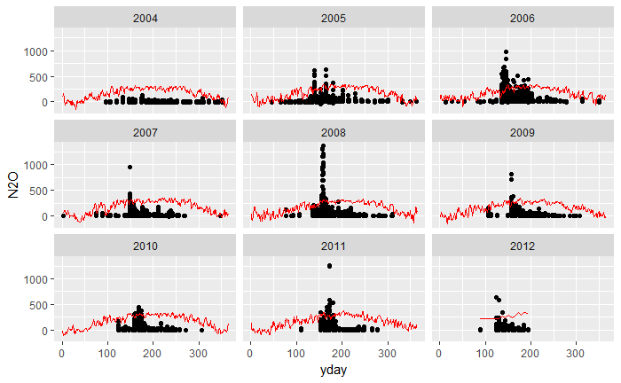

```r
ggplot()+
  geom_point(data = filter(both_ars_cold, town == "West_Lafayette"& year.y %in% c(2004:2012)), aes(x=yday, y=N2O))+
  geom_line(data = filter(both_ars_cold, town == "West_Lafayette"& year.y %in% c(2004:2012)),
            aes(x=yday, y=(daymet_tmax*10)), color="red")+
  facet_wrap(~year.y)
```

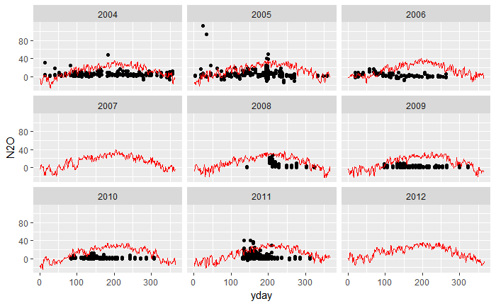

```r
ggplot()+
  geom_point(data = filter(both_ars_cold, town == "Mandan"& year.y %in% c(2004:2012)), aes(x=yday, y=N2O))+
  geom_line(data = filter(both_ars_cold, town == "Mandan"& year.y %in% c(2004:2012)),
            aes(x=yday, y=(daymet_tmax)), color="red")+
  facet_wrap(~year.y)
```

## What’s important

Need dataframe with: site, year, day, N2O, min temp, max temp, avg temp, radiation, sand, silt, clay, organic matter, latitude, soil moisture, precipitation

What is the definition of a peak?  
Number of days over average for each year Greatest day over average for each year  
Greatest single value

What is the definition of a thaw? Soil temp above 0C - for how long?  
If no soil temp, will need to choose air temp  
Set day after which “thaw” is not an issue

What are antecedant conditions?  
Lowest temp Freezing hours  
Duration of freeze Frequency of freeze-thaws

What are my assumptions? Soil is saturated at thaw Thaw speed is the same?

How does radiation play into everything?  
Temp on day of peak?

What do I do about missed peaks?

Are IN peaks from fertilizer at planting? Probably.

I need more data from Canada. My NY data? Iowa data? Duxbury data? NEED MORE DATA.

Look at Johnson’s paper.

## Other questions

Latitude and N2O Soil texture  
Soil CN

```r
datain<-read_csv("../data/KBS.csv", skip=19)
colnames(datain)<-c("date", "trt", "rep", "CH4", "CO2", "N2O_N", "year", "temp", "crop")
datain$day<-yday(datain$date)
```

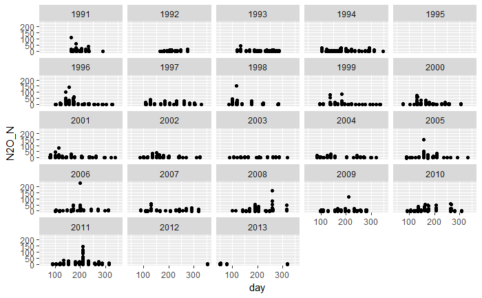

```r
ggplot(datain, aes(x=day, y = N2O_N))+
         geom_jitter()+
         facet_wrap(~year)
```

http://www.n2o.net.au/information/for-researchers/ rDataOne

Flechard C.R., P. Ambus, U. Skiba, R.M. Rees, A. Hensen, A. van Amstel, A. van den Pol-van Dasselaar, J.-F. Soussana, M. Jones, J. Clifton-Brown, A. Raschi, L. Horvath, A. Neftel, M. Jocher, C. Ammann, J. Leifeld, J. Fuhrer, P. Calanca, E. Thalman, K. Pilegaard, et al. (2007) Effects of climate and management intensity on nitrous oxide emissions in grassland systems across Europe. Agriculture, Ecosystems and Environment, 121(1-2) 135-152

Pihlatie M, 2007: Nitrous oxide emissions from selected natural and managed northern ecosystems. University of Helsinki, Department of Environmental Sciences. PhD thesis

Estimates neglecting cold regions + thaw periods miss 17 to 28% of the story.